# R Notebook

# Reminder on descriptive statistics

```r
data(iris)
X = iris$Sepal.Length
```

It tells a vert different story with the histogram if we use the different number of breaks:

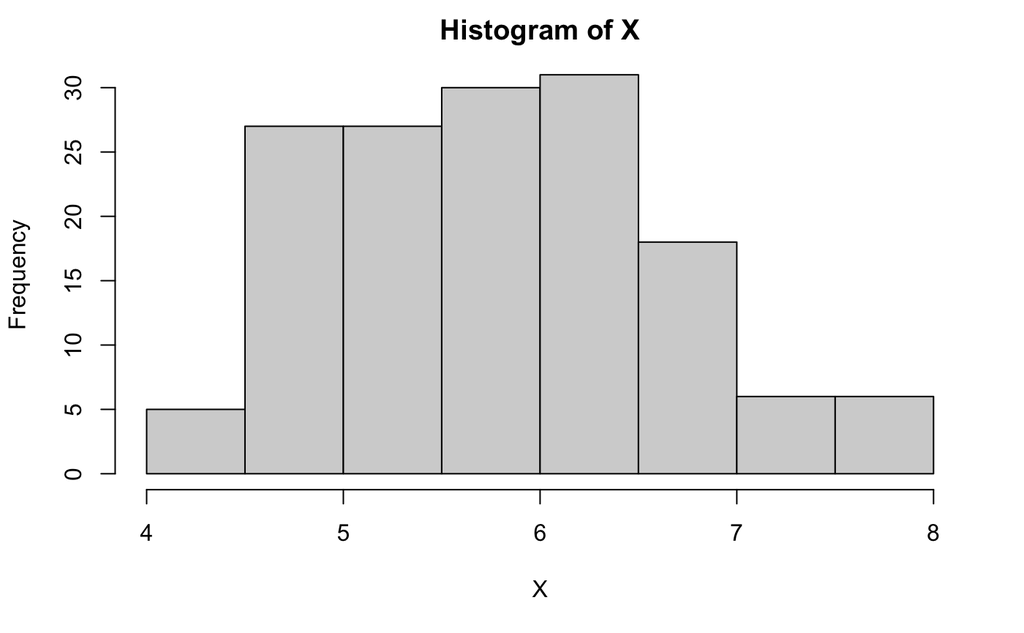

```r
hist(X, breaks=nclass.FD(X))
```

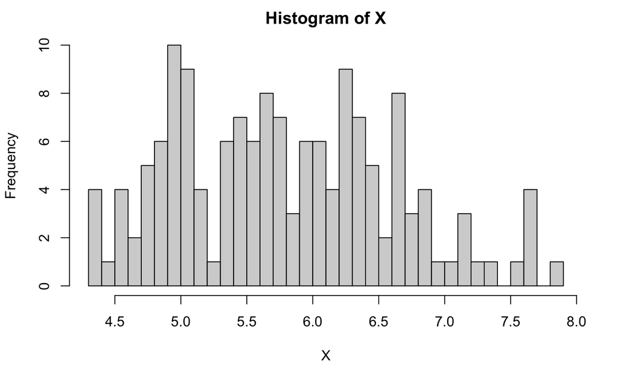

```r
hist(X, breaks=40)
```

The selection of the number of slices can be performed automatically in R with at least 3 different algorithms

It is also interesting to combine the histogram with an estimation of the pdf function mode by ‘density’:

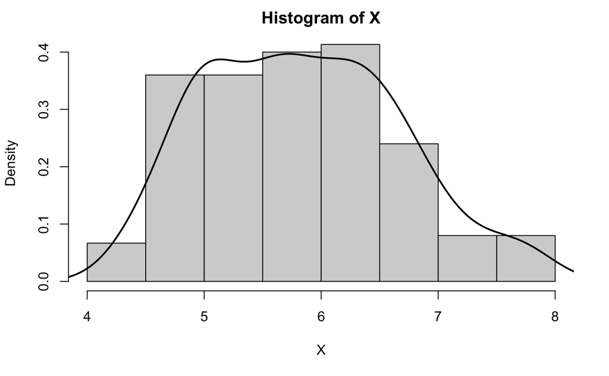

```r
hist(X, freq=FALSE)
lines(density(X), col=2, lwd=2)
```

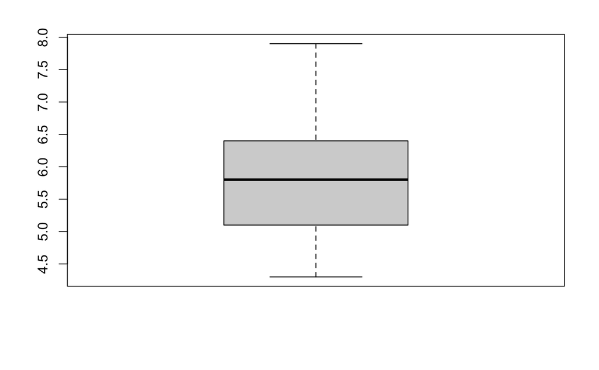

```r
boxplot(X)
```

```r
par(mfrow=c(2,1))
hist(X, freq=FALSE)
lines(density(X), col=2, lwd=2)
```

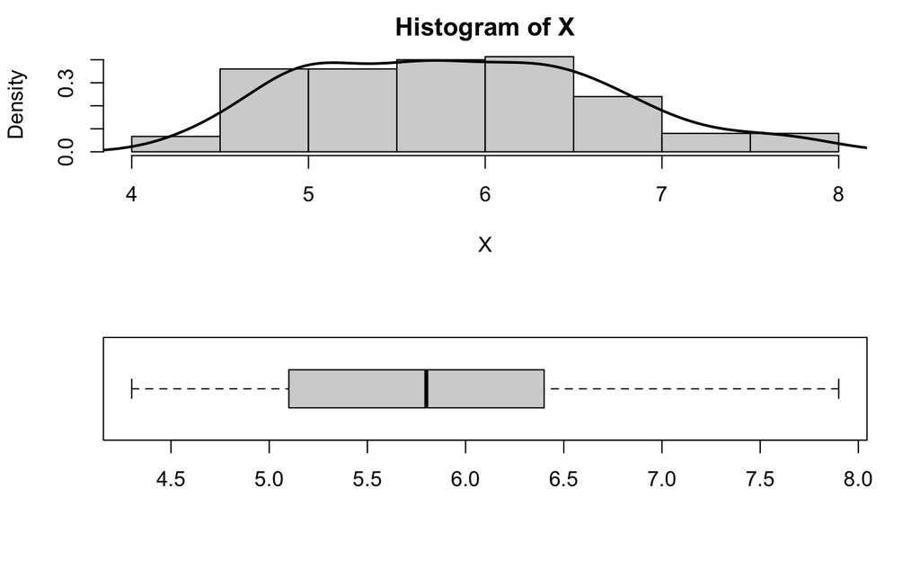

```r
boxplot(X, horizontal=TRUE)
```

Regarding multivariate data, it is possible for the iris data to plot several boxplots side by side because the 4 variables are all expressed on the same unit(cm).

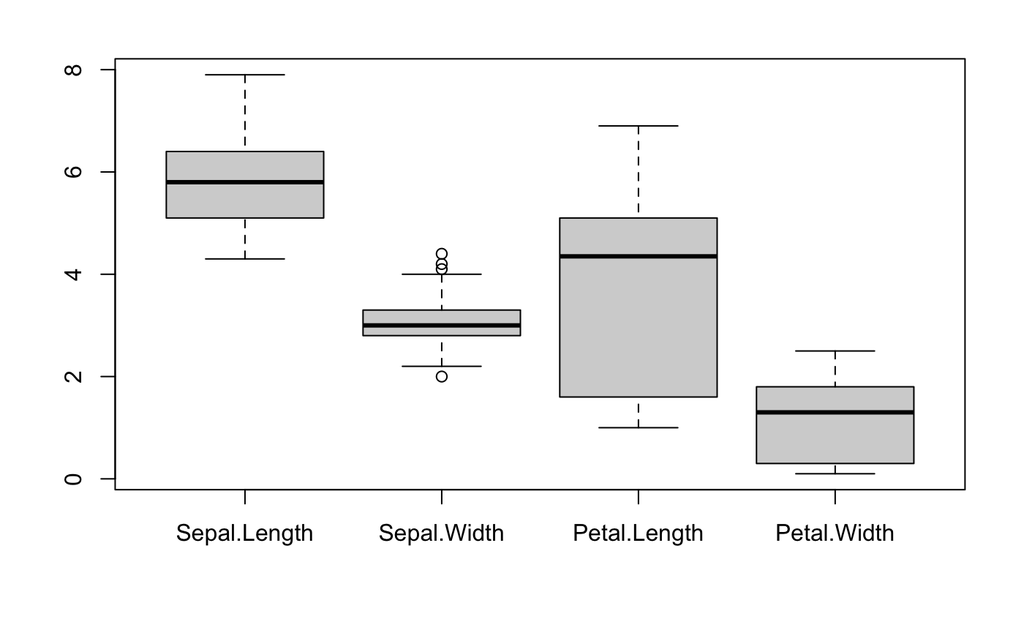

```r
boxplot(iris[,-5])
```

The alternative would be:

```r
par(mfrrow=c(2,2))
```

```
"mfrrow" is not a graphical parameter
```

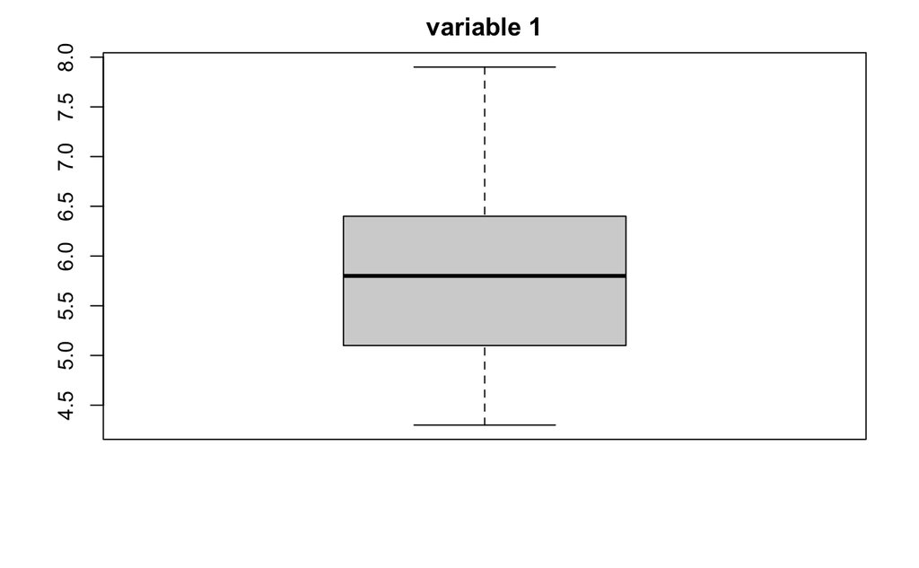

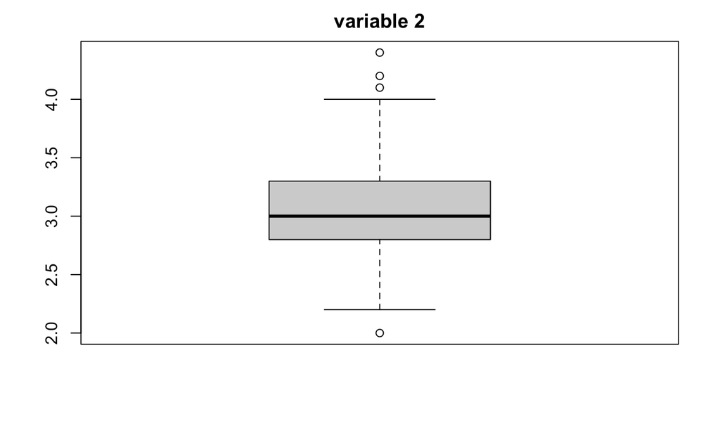

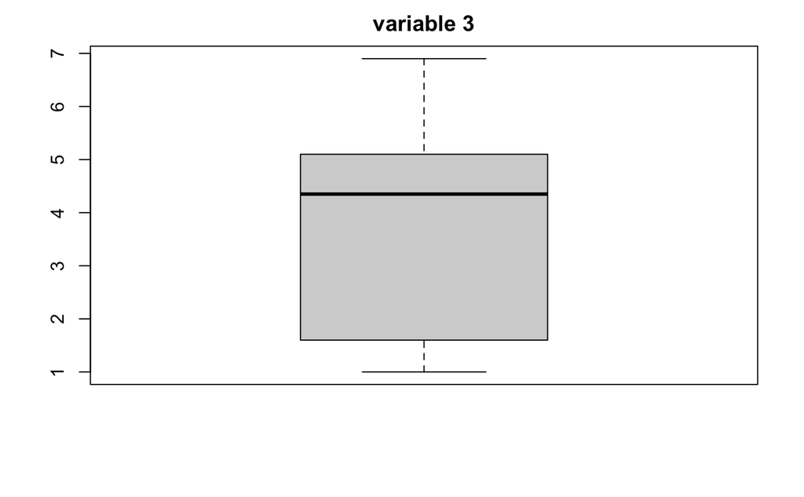

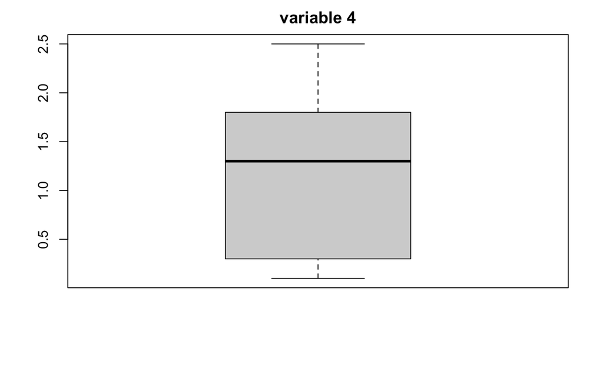

```r
for (j in 1:4) boxplot(iris[,j], main=paste("variable", j))
```

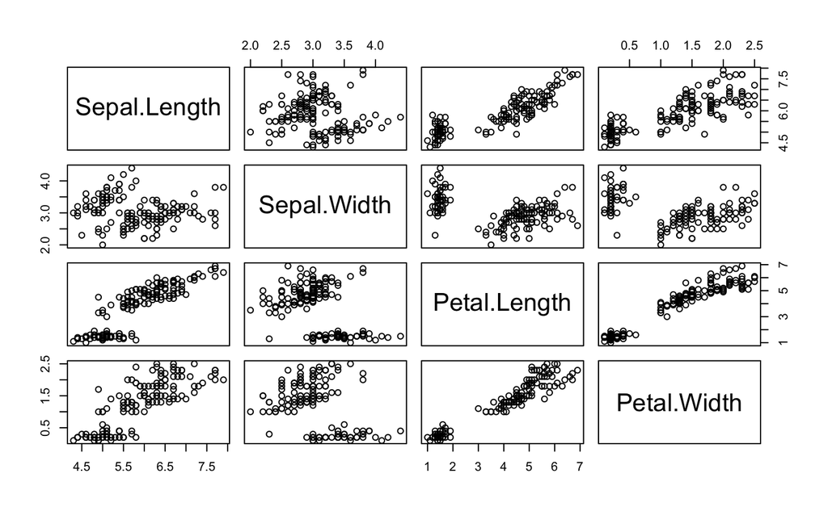

```r
plot(iris[,-5])
```

It is possible to add to this plot an additional species):

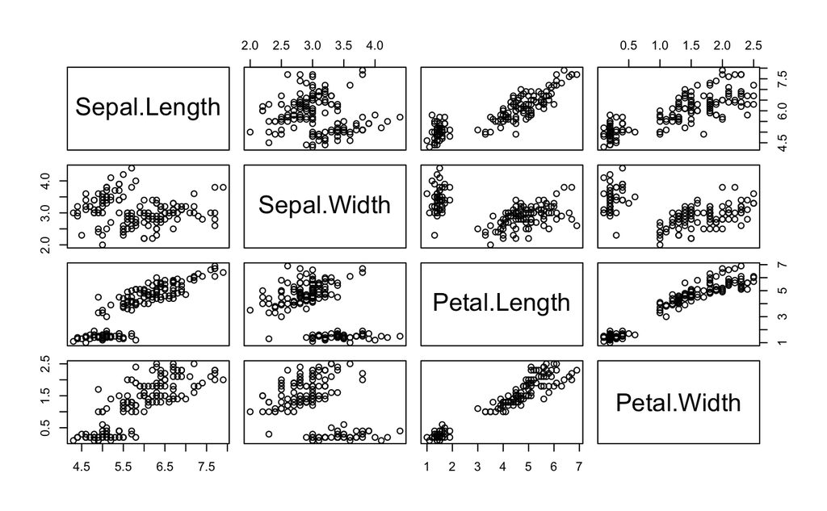

```r
plot(iris[,-5], col=as.numeric(iris$Species))
```

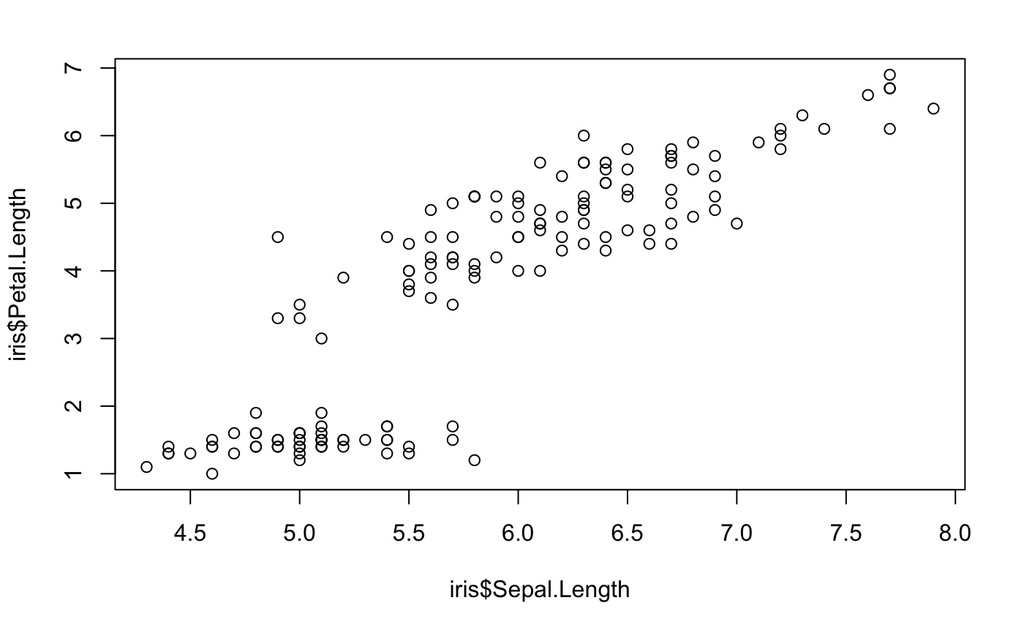

```r
plot(iris$Sepal.Length, iris$Petal.Length, col=as.numeric(iris$Species))
```

Mean of each variable

```r
data(iris)
mu = colMeans(iris[, -5])
mu
```

```
Sepal.Length  Sepal.Width Petal.Length  Petal.Width
    5.843333     3.057333     3.758000     1.199333
```

```r
# Cannot use mean function as it calculates mean of all values and returns scalar
## Multivariate numerical indicators
```

Covariance and correlation matrices:

```r
S = cov(iris[,-5])
S
```

```
             Sepal.Length Sepal.Width Petal.Length Petal.Width
Sepal.Length    0.6856935  -0.0424340    1.2743154   0.5162707
Sepal.Width    -0.0424340   0.1899794   -0.3296564  -0.1216394
Petal.Length    1.2743154  -0.3296564    3.1162779   1.2956094
Petal.Width     0.5162707  -0.1216394    1.2956094   0.5810063
```

```r
C = cor(iris[,-5])
C
```

```
             Sepal.Length Sepal.Width Petal.Length Petal.Width
Sepal.Length    1.0000000  -0.1175698    0.8717538   0.8179411
Sepal.Width    -0.1175698   1.0000000   -0.4284401  -0.3661259
Petal.Length    0.8717538  -0.4284401    1.0000000   0.9628654
Petal.Width     0.8179411  -0.3661259    0.9628654   1.0000000
```

# The learning process in supervised classification

## LDA and logistic regression

Let’s first apply LDA on the iris data:

```r
data(iris)
X = iris[,-5]
Y = as.numeric(iris$Species)

library(MASS)
system.time((f = lda(X,Y)))
```

```
   user  system elapsed
  0.002   0.000   0.004
```

After the learning, it is possible to examine the output:

```r
f
```

```
Call:
lda(X, Y)

Prior probabilities of groups:
        1         2         3
0.3333333 0.3333333 0.3333333

Group means:
  Sepal.Length Sepal.Width Petal.Length Petal.Width
1        5.006       3.428        1.462       0.246
2        5.936       2.770        4.260       1.326
3        6.588       2.974        5.552       2.026

Coefficients of linear discriminants:
                    LD1         LD2
Sepal.Length  0.8293776  0.02410215
Sepal.Width   1.5344731  2.16452123
Petal.Length -2.2012117 -0.93192121
Petal.Width  -2.8104603  2.83918785

Proportion of trace:
   LD1    LD2
0.9912 0.0088
```

Call: lda(X, Y)

Afterward, if we would like to classify a new observation, we have to call the `predict` fuction:

```r
xstar = c(6, 2.9, 5, 3) # Four variable to make one new observation
ystar = predict(f, xstar)
ystar
```

```
$class
[1] 3
Levels: 1 2 3

$posterior
                1            2 3
[1,] 1.980211e-52 8.745769e-10 1

$x
           LD1      LD2
[1,] -7.906095 3.618209
```

Posterior probability is the class it is classified as →3 in this case

```r
f = lda(X,Y, cv=TRUE)
predict(f, xstar)
```

```
$class
[1] 3
Levels: 1 2 3

$posterior
                1            2 3
[1,] 1.980211e-52 8.745769e-10 1

$x
           LD1      LD2
[1,] -7.906095 3.618209
```

```r
n = nrow(X)
learn = sample(1:n, 2/3*n)
f <- lda(X[learn,], Y[learn])
ystar = predict(f, X[-learn,])

# Compute the classification error
err = sum(Y[-learn] != ystar$class) / length(ystar$class)
err
```

```
[1] 0
```

There is no error in this case, model parfectly predict the class of each observation

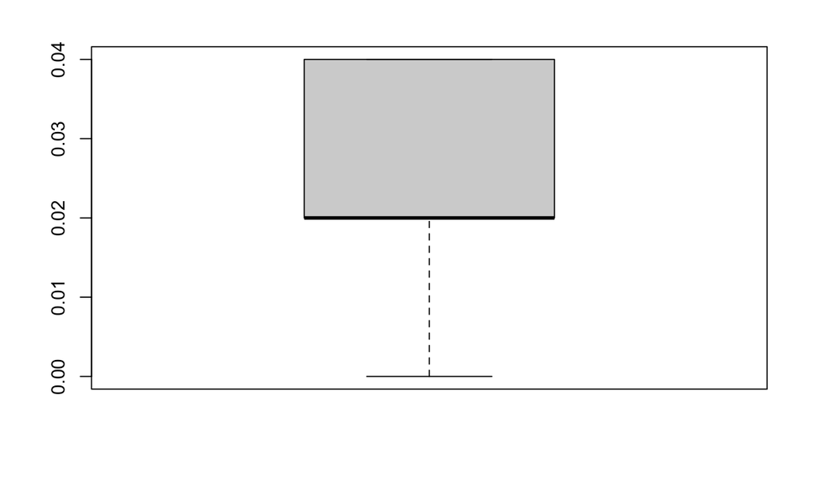

```r
n = nrow(X)
err = c()
for (i in 1:10){
  learn = sample(1:n, 2/3*n)
  f <- lda(X[learn,], Y[learn])
  ystar = predict(f, X[-learn,])

  # Compute the classification error

  err[i] = sum(Y[-learn] != ystar$class) / length(ystar$class)
}
boxplot(err)
```